# 基于决策树的在线新闻热度预测

司徒雪颖——中央财经大学

2017年12月27日

## 研究目的

随着互联网的发展，互联网媒体越来越受人们的关注。互联网信息具有量大、传播速度快的特点。一篇在线新闻可以在几天之内获得几十甚至上百万转发量，拥有极高的关注度，但与此同时，有的新闻则关注者寥寥。找到影响在线新闻热度的影响因素并提前预测在线新闻热度具有重要意义。对于政府的舆情监控系统来说，新闻热度的早期预测可以帮助舆情动向，及早发现并控制虚假、负面热点新闻，避免造成社会的不安定因素；对于作者来说，一方面可以帮助发掘更多具有价值的新闻话题，另一方面也可以据此更好地组织自己的文章，使之获得更广泛的关注；对于内容提供商来说，可以更好地挖掘用户需求，将此运用到内容选择、新闻推介等方面，吸引更多用户，扩大影响力；对于对于广告商来说，可以依据新闻热度的预测来设计广告宣传方案，合理安排广告投放；商家、社会活动组织者等也可以据此提前了解社会热点，做出关于广告投放、产品设计、活动宣传方案等方面的决策。

一篇在线新闻的热度有非常多的影响因素，其影响方式也比较复杂，而且很多影响因素之间也具有相关性，为数据分析带来了很大的困难。一方面，很多影响因素存在于新闻文本本身，所以如何提取这些关键信息也很棘手，另一方面，在线新闻热度还与当时外部政治、经济、文化环境等相关，因而新闻发布的时机、发布的渠道等等诸多因素也会影响新闻如何提取、量化这些信息都为新闻热度预测带来挑战。因此，新闻热度的预测需要比较复杂的文本处理、数据分析技术，使得机器学习方法在该领域有非常广泛的应用。

## 读入数据

```r
library(e1071)
library(corrplot)
library(reshape2)#重构和整合数据集的工具包
library(ggplot2)
library(tree)
library(randomForest)
setwd("E:/graduate/class/data_mining_machine_learning/gunannan/OnlineNewsPopularity/")
# getwd()
news = read.csv("OnlineNewsPopularity.csv")
dim(news)
```

```
## [1] 39644    61
```

```r
head(news,2)
```

```
##                                                            url timedelta
## 1 http://mashable.com/2013/01/07/amazon-instant-video-browser/       731
## 2  http://mashable.com/2013/01/07/ap-samsung-sponsored-tweets/       731
##   n_tokens_title n_tokens_content n_unique_tokens n_non_stop_words
## 1             12              219       0.6635945                1
## 2              9              255       0.6047431                1
##   n_non_stop_unique_tokens num_hrefs num_self_hrefs num_imgs num_videos
## 1                0.8153846         4              2        1          0
## 2                0.7919463         3              1        1          0
##   average_token_length num_keywords data_channel_is_lifestyle
## 1             4.680365            5                         0
## 2             4.913725            4                         0
##   data_channel_is_entertainment data_channel_is_bus data_channel_is_socmed
## 1                             1                   0                      0
## 2                             0                   1                      0
##   data_channel_is_tech data_channel_is_world kw_min_min kw_max_min
## 1                    0                     0          0          0
## 2                    0                     0          0          0
##   kw_avg_min kw_min_max kw_max_max kw_avg_max kw_min_avg kw_max_avg
## 1          0          0          0          0          0          0
## 2          0          0          0          0          0          0
##   kw_avg_avg self_reference_min_shares self_reference_max_shares
## 1          0                       496                       496
## 2          0                         0                         0
##   self_reference_avg_sharess weekday_is_monday weekday_is_tuesday
## 1                        496                 1                  0
## 2                          0                 1                  0
##   weekday_is_wednesday weekday_is_thursday weekday_is_friday
## 1                    0                   0                 0
## 2                    0                   0                 0
##   weekday_is_saturday weekday_is_sunday is_weekend    LDA_00     LDA_01
## 1                   0                 0          0 0.5003312 0.37827893
## 2                   0                 0          0 0.7997557 0.05004667
##       LDA_02     LDA_03     LDA_04 global_subjectivity
## 1 0.04000468 0.04126265 0.04012254           0.5216171
## 2 0.05009625 0.05010067 0.05000071           0.3412458
##   global_sentiment_polarity global_rate_positive_words
## 1                0.09256198                 0.04566210
## 2                0.14894781                 0.04313725
##   global_rate_negative_words rate_positive_words rate_negative_words
## 1                 0.01369863           0.7692308           0.2307692
## 2                 0.01568627           0.7333333           0.2666667
##   avg_positive_polarity min_positive_polarity max_positive_polarity
## 1             0.3786364            0.10000000                   0.7
## 2             0.2869146            0.03333333                   0.7
##   avg_negative_polarity min_negative_polarity max_negative_polarity
## 1              -0.35000                -0.600                  -0.2
## 2              -0.11875                -0.125                  -0.1
##   title_subjectivity title_sentiment_polarity abs_title_subjectivity
## 1                0.5                  -0.1875                    0.0
## 2                0.0                   0.0000                    0.5
##   abs_title_sentiment_polarity shares
## 1                       0.1875    593
## 2                       0.0000    711
```

## 变量介绍

数据集的中英文变量名对照在附录

| 自变量 |  | 类型（变量数） |
| --- | --- | --- |
| 与字数相关 | 标题字数 | 定量（1） |
|  | 文章字数 | 定量（1） |
|  | 单词平均长度 | 定量（1） |
|  | 只出现一次的单词的比例 | 比例（1） |
|  | 只出现一次且为非停用词的比例 | 比例（1） |
| 与链接相关 | 文章链接数（例如多种社交网站中） | 定量（1） |
|  | 含有Mashable网其他文章的链接数目 | 定量（1） |
|  | 文章引用的Mashable网站的其他文章的最大、最小和平均转发量 | 定量（3） |
| 与媒体相关 | 含有图片数目 | 定量（1） |
|  | 含有视频数目 | 定量（1） |
| 与时间相关 | 发布时间是否在星期几 | 布尔（7） |
|  | 发布时间是否在周末 | 布尔（1） |
| 与关键字相关 | 关键字数目 | 定量（1） |
|  | 文章中最冷门关键字最大、最小和平均转发量 | 定量（3） |
|  | 文章中普通关键字最大、最小和平均转发量 | 定量（3） |
|  | 文章中最热门关键字最大、最小和平均转发量 | 定量（3） |
|  | 文章的类型：是否为（娱乐、科技等）类型 | 布尔（1） |
| 与内容相关 | 与前五个最相关的主题的相关程度 | 比例（5） |
|  | 标题主观性 | 比例（1） |
|  | 文章内容主观性和两极化得分及其绝对水平 | 比例（4） |
|  | 非中性词中肯定词、否定词的比重 | 比例（2） |
|  | 肯、否定词的两极化（最大、最小和平均）水平 | 比例（6） |
| 因变量 |  | 类型 |
|  | 文章是否受欢迎 | 定量（1） |

## 描述统计

### 相关图矩阵

- 可以看到，n_unique_tokens n_non_stop_words n_non_stop_unique_tokens相关性强 self_reference_min_shares self_reference_max_shares self_reference_avg_sharess相关性强，因此稍后考虑删除一些变量。

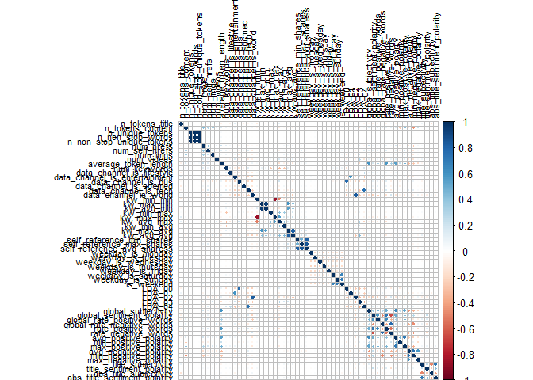

```r
mcor = cor(news[,3:60])
# corrplot(mcor,order = "hclust",tl.col = "black",tl.cex = 0.7)
corrplot(mcor,tl.col = "black",tl.cex = 0.7)
```

### 频道类别与分享数的关系

```r
news.proc = news[,c(14:19,32:39,dim(news)[2])]
strlist = strsplit(names(news.proc[,-15]),split = "_")
newname = NULL
for(list in strlist)
{
  newname = c(newname,list[length(list)])
}
colnames(news.proc) = c(newname,"shares")
head(news.proc)
```

```
##   lifestyle entertainment bus socmed tech world monday tuesday wednesday
## 1         0             1   0      0    0     0      1       0         0
## 2         0             0   1      0    0     0      1       0         0
## 3         0             0   1      0    0     0      1       0         0
## 4         0             1   0      0    0     0      1       0         0
## 5         0             0   0      0    1     0      1       0         0
## 6         0             0   0      0    1     0      1       0         0
##   thursday friday saturday sunday weekend shares
## 1        0      0        0      0       0    593
## 2        0      0        0      0       0    711
## 3        0      0        0      0       0   1500
## 4        0      0        0      0       0   1200
## 5        0      0        0      0       0    505
## 6        0      0        0      0       0    855
```

- 从图中可以看出，有6134多个没有频道类别，社交频道的新闻更容易获得高分享数

```r
channel = matrix("unclassified",dim(news.proc)[1],1)
for(i in 1:6)
{
  channel[news.proc[,i]==1] = names(news.proc[1:6])[i]
}
table(channel)
```

```
## channel
##           bus entertainment     lifestyle        socmed          tech
##          6258          7057          2099          2323          7346
##  unclassified         world
##          6134          8427
```

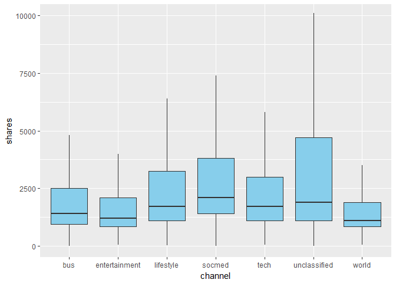

```r
news = cbind(news,channel)
ggplot(news,aes(channel,shares))+coord_cartesian(ylim=c(0,10000))+
  geom_boxplot(fill = I("skyblue"),outlier.shape = NA)
```

### 发布时间与分享数的关系

- 周末新闻的分享数明显高于工作日

```r
weekday = matrix(0,dim(news.proc)[1],1)
for(i in 7:13)
{
  weekday[news.proc[,i]==1] = names(news.proc)[i]
}
table(weekday)
```

```
## weekday
##    friday    monday  saturday    sunday  thursday   tuesday wednesday
##      5701      6661      2453      2737      7267      7390      7435
```

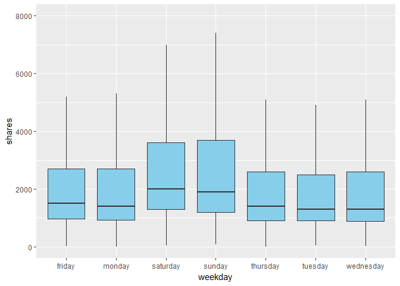

```r
news = cbind(news,weekday)
ggplot(news,aes(weekday,shares))+coord_cartesian(ylim=c(0,8000))+
  geom_boxplot(fill = I("skyblue"),outlier.shape = NA)
```

## 建立模型

### 删除相关性强的变量

- n_unique_tokens n_non_stop_words n_non_stop_unique_tokens相关性太强，只保留 n_unique_tokens（其他强相关性变量删除情况参见附录）
- 发布时间与新闻频道本为one-hot形式，现在归并为定性变量

```r
dele_var_names = c("n_non_stop_words","n_non_stop_unique_tokens",
                   "self_reference_min_shares","self_reference_max_shares",
                   "kw_min_min", "kw_max_min","kw_max_avg")

dele_var_num = which(names(news) %in% dele_var_names)

news2 = news[,-c(1,2,dele_var_num,14:19,32:39)]
```

- 阈值设为1400，分享数高于1400的新闻则认为是热门新闻，低于1400则认为是非热门新闻
- 之所以设为1400是因为这样能使得热门新闻与非热门新闻的数量几乎各占一半，有利于提高预测结果

```r
D1 = 1400
news2$shares[news$shares>D1] = "popular"
news2$shares[news$shares<=D1] = "unpopular"
news2$shares = as.factor(news2$shares)
table(news2$shares) #一半一半
```

```
##
##   popular unpopular
##     19562     20082
```

```r
head(news2,2)
```

```
##   n_tokens_title n_tokens_content n_unique_tokens num_hrefs num_self_hrefs
## 1             12              219       0.6635945         4              2
## 2              9              255       0.6047431         3              1
##   num_imgs num_videos average_token_length num_keywords kw_avg_min
## 1        1          0             4.680365            5          0
## 2        1          0             4.913725            4          0
##   kw_min_max kw_max_max kw_avg_max kw_min_avg kw_avg_avg
## 1          0          0          0          0          0
## 2          0          0          0          0          0
##   self_reference_avg_sharess    LDA_00     LDA_01     LDA_02     LDA_03
## 1                        496 0.5003312 0.37827893 0.04000468 0.04126265
## 2                          0 0.7997557 0.05004667 0.05009625 0.05010067
##       LDA_04 global_subjectivity global_sentiment_polarity
## 1 0.04012254           0.5216171                0.09256198
## 2 0.05000071           0.3412458                0.14894781
##   global_rate_positive_words global_rate_negative_words
## 1                 0.04566210                 0.01369863
## 2                 0.04313725                 0.01568627
##   rate_positive_words rate_negative_words avg_positive_polarity
## 1           0.7692308           0.2307692             0.3786364
## 2           0.7333333           0.2666667             0.2869146
##   min_positive_polarity max_positive_polarity avg_negative_polarity
## 1            0.10000000                   0.7              -0.35000
## 2            0.03333333                   0.7              -0.11875
##   min_negative_polarity max_negative_polarity title_subjectivity
## 1                -0.600                  -0.2                0.5
## 2                -0.125                  -0.1                0.0
##   title_sentiment_polarity abs_title_subjectivity
## 1                  -0.1875                    0.0
## 2                   0.0000                    0.5
##   abs_title_sentiment_polarity    shares       channel weekday
## 1                       0.1875 unpopular entertainment  monday
## 2                       0.0000 unpopular           bus  monday
```

### 划分训练集测试集

- 训练集、测试集各占一半

```r
set.seed(1234)
train=sample(1:nrow(news2),round(0.5*nrow(news2)))
```

### 决策树

- 决策树的训练错误率为0.385 ，测试错误率为0.383
- 只用了两个划分变量，分别是频道（channel）和文章中最普通关键字平均转发量（kw_avg_avg）

```r
bio.tree=tree(shares~.-shares,news2[train,])
summary(bio.tree)
```

```
##
## Classification tree:
## tree(formula = shares ~ . - shares, data = news2[train, ])
## Variables actually used in tree construction:
## [1] "channel"    "kw_avg_avg"
## Number of terminal nodes:  3
## Residual mean deviance:  1.322 = 26200 / 19820
## Misclassification error rate: 0.385 = 7632 / 19822
```

```r
bio.tree.pred=predict(bio.tree,news2[-train,],type='class')
table(bio.tree.pred,news2[-train,'shares'])
```

```
##
## bio.tree.pred popular unpopular
##     popular      7383      5140
##     unpopular    2448      4851
```

```r
p.tree=sum((bio.tree.pred!=news2[-train,'shares']))/nrow(news2[-train,])
p.tree #预测错误率
```

```
## [1] 0.382807
```

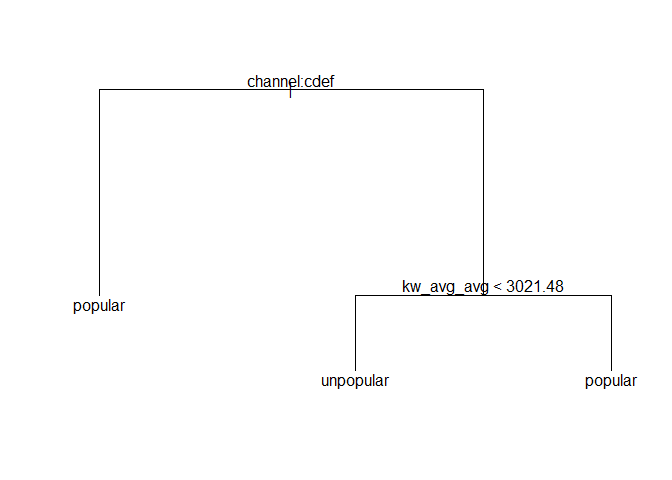

```r
plot(bio.tree)
text(bio.tree)
```

### bagging

- bagging 设置的mtry数为特征数的二次根号
- bagging训练错误率为 0.342，测试错误率为0.337，比决策树提升了5%

```r
bio.bag = randomForest(shares~.,news2[train,],na.action = na.roughfix,
                       mtry = round(sqrt(ncol(news2)-1),0))
bio.bag
```

```
##
## Call:
##  randomForest(formula = shares ~ ., data = news2[train, ], mtry = round(sqrt(ncol(news2) -      1), 0), na.action = na.roughfix)
##                Type of random forest: classification
##                      Number of trees: 500
## No. of variables tried at each split: 6
##
##         OOB estimate of  error rate: 34.16%
## Confusion matrix:
##           popular unpopular class.error
## popular      6340      3391   0.3484739
## unpopular    3381      6710   0.3350510
```

```r
bio.bag.pre = predict(bio.bag,news2[-train,])
table(bio.bag.pre,news2[-train,'shares'])
```

```
##
## bio.bag.pre popular unpopular
##   popular      6509      3352
##   unpopular    3322      6639
```

```r
p.bag=sum((bio.bag.pre!=news2[-train,'shares']))/nrow(news2[-train,])
p.bag #预测错误率
```

```
## [1] 0.3366966
```

### 随机森林

- 随机森林的mtry数为特征数的二次根号，使用了500棵树
- 随机森林训练错误率为 0.34，测试错误率为0.337，与bagging效果相同

```r
bio.rf = randomForest(shares~.,news2[train,],na.action = na.roughfix,
                       importance=T,mtry = round(sqrt(ncol(news2)-1),0),
                       ntree=500)
bio.rf
```

```
##
## Call:
##  randomForest(formula = shares ~ ., data = news2[train, ], importance = T,      mtry = round(sqrt(ncol(news2) - 1), 0), ntree = 500, na.action = na.roughfix)
##                Type of random forest: classification
##                      Number of trees: 500
## No. of variables tried at each split: 6
##
##         OOB estimate of  error rate: 34%
## Confusion matrix:
##           popular unpopular class.error
## popular      6348      3383   0.3476518
## unpopular    3357      6734   0.3326727
```

- 袋外误差、训练集热门新闻预测误差、非热门新闻预测误差随树的棵树增加的变化图

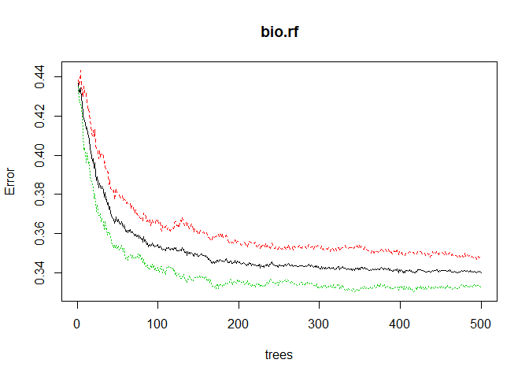

```r
plot(bio.rf)
```

- varImpPlot可实现重要变量可视化。

影响平均精确度下降的重要变量是频道（channel）和文章中最普通关键字平均转发量（kw_avg_avg）；影响平均gini下降得重要变量是文章中最普通关键字平均转发量（kw_avg_avg）和文章引用的Mashable网站的其他文章的平均转发量（self_reference_avg_sharess）

在描述统计时也发现，社交频道的新闻更容易获得高分享数。

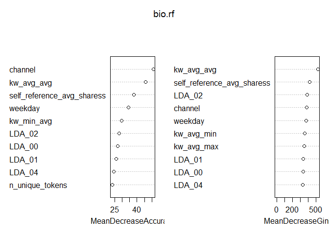

```r
varImpPlot(bio.rf, sort=TRUE,n.var=10)
```

- 预测错误率与bagging效果相同

```r
bio.rf.pre = predict(bio.rf,news2[-train,])
table(bio.rf.pre,news2[-train,'shares'])
```

```
##
## bio.rf.pre  popular unpopular
##   popular      6489      3335
##   unpopular    3342      6656
```

```r
p.rf=sum((bio.rf.pre!=news2[-train,'shares']))/nrow(news2[-train,])
p.rf #预测错误率
```

```
## [1] 0.3368479
```

## 附录

### 因为多个变量强相关而删除变量情况

- n_unique_tokens n_non_stop_words n_non_stop_unique_tokens相关性太强，只保留 n_unique_tokens（其他强相关性变量删除情况参见附录）
- self_reference_min_shares self_reference_max_shares self_reference_avg_sharess相关性太强，只保留self_reference_avg_sharess
- kw_max_max与kw_min_min 强负相关,只保留kw_max_max
- kw_max_min与kw_avg_min强正相关，只保留kw_avg_min
- kw_max_avg与kw_avg_avg强正相关，只保留kw_avg_avg
- 第一第二列数据分别为新闻网址和距爬取新闻的时间，对预测无用，故删除

### 变量信息

1. n_tokens_title: Number of words in the title （标题字数）
2. n_tokens_content: Number of words in the content （文章字数）
3. n_unique_tokens: Rate of unique words in the content （文章唯一单词数（即只出现一次 的单词）的比例，0到1之间）
4. n_non_stop_unique_tokens: Rate of unique non-stop words in the content （文章中唯一出现的且为非停用词:可检索或爬虫得到的词 的比例）
5. num_hrefs: Number of links （文章链接数）
6. num_self_hrefs: Number of links to other articles published by Mashable （文章中关于Mashable发布的其他文章的链接数）
7. num_imgs: Number of images （图片数）
8. num_videos: Number of videos （视频数）
9. average_token_length: Average length of the words in the content （平均每个词的长度）
10. num_keywords: Number of keywords in the metadata （元数据的关键词数）
11. data_channel_is_lifestyle: Is data channel ‘Lifestyle’? （生活服务类链接 是1否0）
12. data_channel_is_entertainment: Is data channel ‘Entertainment’? （娱乐类链接）
13. data_channel_is_bus: Is data channel ‘Business’? （商业类链接）
14. data_channel_is_socmed: Is data channel ‘Social Media’? （社交媒体类）
15. data_channel_is_tech: Is data channel ‘Tech’? （科技类）
16. data_channel_is_world: Is data channel ‘World’? （全球类）
17. kw_min_min: Worst keyword (min. shares) （该文章中最冷门的关键字里的最小转发量）
18. kw_max_min: Worst keyword (max. shares)
19. kw_avg_min: Worst keyword (avg. shares)
20. kw_min_max: Best keyword (min. shares)
21. kw_max_max: Best keyword (max. shares)
22. kw_avg_max: Best keyword (avg. shares)
23. kw_min_avg: Avg. keyword (min. shares)
24. kw_max_avg: Avg. keyword (max. shares)
25. kw_avg_avg: Avg. keyword (avg. shares)
26. self_reference_min_shares: Min. shares of referenced articles in Mashable （文章引用的 参考文章的最小转发量）
27. self_reference_max_shares: Max. shares of referenced articles in Mashable
28. self_reference_avg_sharess: Avg. shares of referenced articles in Mashable
29. weekday_is_monday: Was the article published on a Monday? （是否周一发布）
30. weekday_is_tuesday: Was the article published on a Tuesday?
31. weekday_is_wednesday: Was the article published on a Wednesday?
32. weekday_is_thursday: Was the article published on a Thursday?
33. weekday_is_friday: Was the article published on a Friday?
34. weekday_is_saturday: Was the article published on a Saturday?
35. weekday_is_sunday: Was the article published on a Sunday?
36. is_weekend: Was the article published on the weekend? （是否周末发布）
37. LDA_00: Closeness to LDA topic 0 （得出五个相关性最大的主题，计算与每个主题的接近性）
38. LDA_01: Closeness to LDA topic 1
39. LDA_02: Closeness to LDA topic 2
40. LDA_03: Closeness to LDA topic 3
41. LDA_04: Closeness to LDA topic 4
42. global_subjectivity: Text subjectivity （文章的主观性，0到1之间）
43. global_sentiment_polarity: Text sentiment polarity （文章观点的两极化，-1到1之间）
44. global_rate_positive_words: Rate of positive words in the content （肯定词的比重）
45. global_rate_negative_words: Rate of negative words in the content （否定词的比重）
46. rate_positive_words: Rate of positive words among non-neutral tokens （非中性词中肯定词的比重，对应每篇文章，该变量与下一变量值加和为一）
47. rate_negative_words: Rate of negative words among non-neutral tokens
48. avg_positive_polarity: Avg. polarity of positive words （肯定词的平均极性，0到1之间）
49. min_positive_polarity: Min. polarity of positive words
50. max_positive_polarity: Max. polarity of positive words
51. avg_negative_polarity: Avg. polarity of negative words （否定词的平均极性，-1到0之间）
52. min_negative_polarity: Min. polarity of negative words
53. max_negative_polarity: Max. polarity of negative words
54. title_subjectivity: Title subjectivity （标题主观性）
55. title_sentiment_polarity: Title polarity （标题的两极化，-1到1之间）
56. abs_title_subjectivity: Absolute subjectivity level （内容的绝对主观性水平）
57. abs_title_sentiment_polarity: Absolute polarity level （内容的绝对两极化水平）
58. shares: Number of shares (target) （转发量）
59. Popular: was the article popular? （文章是否受欢迎，是即转发量大于等于1400为1,否为-1。此变量为分类算法的因变量）